# Chapter 6 Homework

Author

Kaylynn Hiller

Published

February 23, 2026

## Setup

```
here() starts at /Users/kaylynnhiller/Desktop/Stats1
```

## Data

This homework uses a built-in dataset from base R (`state.x77`). Run the code below to create the working tibble `states`.

Throughout, use:

- outcome: `life_exp`
- predictor: `murder`

# Question 1: Descriptive statistics

## 1a. Descriptive statistics (psych)

Use `psych::describe()` (or something else if you want) to get descriptive statistics for `life_exp` and `murder`.

```
   vars  n  mean   sd median trimmed  mad   min  max range  skew kurtosis   se
X1    1 50 70.88 1.34  70.67   70.92 1.54 67.96 73.6  5.64 -0.15    -0.67 0.19
```

```
   vars  n mean   sd median trimmed  mad min  max range skew kurtosis   se
X1    1 50 7.38 3.69   6.85     7.3 5.19 1.4 15.1  13.7 0.13    -1.21 0.52
```

## 1b. Descriptive statistics (tidyverse)

Compute (at minimum) the mean and standard deviation of `life_exp` and `murder` using `summarize()`.

```
# A tibble: 1 × 6
  mean_life var_life sd_life mean_murder var_murder sd_murder
      <dbl>    <dbl>   <dbl>       <dbl>      <dbl>     <dbl>
1      70.9     1.80    1.34        7.38       13.6      3.69
```

# Question 2a: Regression and model comparison

You will evaluate whether `murder` predicts `life_exp`.

## 2a(i). Write the model comparison and null hypothesis

Write Model C and Model A in words and equations, and state the null hypothesis.

A typical setup for testing whether a slope is needed is:

- Model C (constrained): slope fixed at 0
- Model A (augmented): slope estimated from the data

Use the notation below (fill in the missing pieces in your write-up):

Model C:
$$Y_i = \beta_0 + \varepsilon_i$$

Model A:
$$Y_i = \beta_0 + \beta_1 X_i + \varepsilon_i$$

Null hypothesis (in symbols and words): our null hypothesis is that murder has no linear effect on life expectancy
$$H_0: \beta_1 = 0$$

## 2a(ii). Fit both models

## 2a(iii). Compute SSE(C), SSE(A), PRE, and F

Compute:

- $\mathrm{SSE}_C$ and $\mathrm{SSE}_A$ from the fitted models
- $\mathrm{PRE} = (\mathrm{SSE}_C - \mathrm{SSE}_A)/\mathrm{SSE}_C$
- the model-comparison $F$ statistic

Use `deviance()` for SSE (RSS) and `df.residual()` as needed.

$$F = \frac{(\mathrm{SSE}_C - \mathrm{SSE}_A)/(P_A - P_C)}{\mathrm{SSE}_A/(n - P_A)}.$$

```
[1] 49
```

```
[1] 48
```

```
[1] 74.98865
```

```
Analysis of Variance Table

Model 1: life_exp ~ 1
Model 2: life_exp ~ 1 + murder
  Res.Df    RSS Df Sum of Sq      F   Pr(>F)
1     49 88.299
2     48 34.461  1    53.838 74.989 2.26e-11 ***
---
Signif. codes:  0 '***' 0.001 '**' 0.01 '*' 0.05 '.' 0.1 ' ' 1
```

```
[1] 2.26007e-11
```

```
[1] "2.2601e-11"
```

|  | MC | MA |
| --- | --- | --- |
| (Intercept) | 70.879 | 72.974 |
|  | (0.190) | (0.270) |
| murder |  | -0.284 |
|  |  | (0.033) |
| Num.Obs. | 50 | 50 |
| R2 | 0.000 | 0.610 |
| F |  | 74.989 |
| p-value |  | 0.000 |

## 2a(iv). Write the prediction equation and interpret coefficients

Write the prediction equation implied by Model A:

$$\widehat{\text{life_exp}} = 72.974 - 0.284 (\text{murder})$$

Interpret:

- the intercept: a state with no murders would have an expected life expectancy of 72.974 years
- the slope: in the 50 states measured, for every 1 unit increase in murders per 100,000 residents life expectancy decreases by 0.284 years

## 2a(v). Conclusion

State:

- statistical conclusion (report $F$ or $t$, PRE, and $p$)
  - F -> 74.989
  - PRE -> 0.610
  - p -> 2.26007e-11
- substantive conclusion (in plain language)
  - According to these results, we reject the null hypothesis that murder rates have no linear relationship with life expectancy for the 50 states.

# Question 2b: Center the predictor

Create a centered version of murder:

## 2b(i). Create `murder_c` and refit the model

## 2b(ii). Report SSE(A), SSE(C), PRE, and F again

Compute the same fit statistics (SSE, PRE, F). Compare them to the results from Question 2a.

```
[1] 74.98865
```

```
Analysis of Variance Table

Model 1: life_exp ~ 1
Model 2: life_exp ~ 1 + murder_c
  Res.Df    RSS Df Sum of Sq      F   Pr(>F)
1     49 88.299
2     48 34.461  1    53.838 74.989 2.26e-11 ***
---
Signif. codes:  0 '***' 0.001 '**' 0.01 '*' 0.05 '.' 0.1 ' ' 1
```

```
[1] 2.26007e-11
```

|  | MC | MA |
| --- | --- | --- |
| (Intercept) | 70.879 | 70.879 |
|  | (0.190) | (0.120) |
| murder_c |  | -0.284 |
|  |  | (0.033) |
| Num.Obs. | 50 | 50 |
| R2 | 0.000 | 0.610 |
| F |  | 74.989 |
| p-value |  | 0.000 |

All statistics in this model are the same as the previous model A except for the intercept of model A. This is not surprising as our model did not change besides being centered on the mean value of murder rates.

## 2b(iii). Interpret coefficients after centering

Write the prediction equation for the centered model and interpret the intercept and slope.

$$\widehat{\text{life_exp}} = 70.879 - 0.284 (\text{murder})$$

In particular: what does the intercept represent *now*?

The intercept is now the predicted life expectancy based on the average murder rate of the state. The slope is the same but instead needs to be interpreted as for every 1 unit increase in murders per 100,000 over the average murder rate, life expectancy decreases by 0.284 years.

## 2b(iv). Plot and compare

Make two scatterplots with regression lines:

1. `life_exp` vs. `murder`
2. `life_exp` vs. `murder_c`

How are these plots different?

The only difference is in the x axis. In the first plot, the murder rate ranges from the minimum and maximum values in the data set. In the second plot, the murder rate is centered on 0.

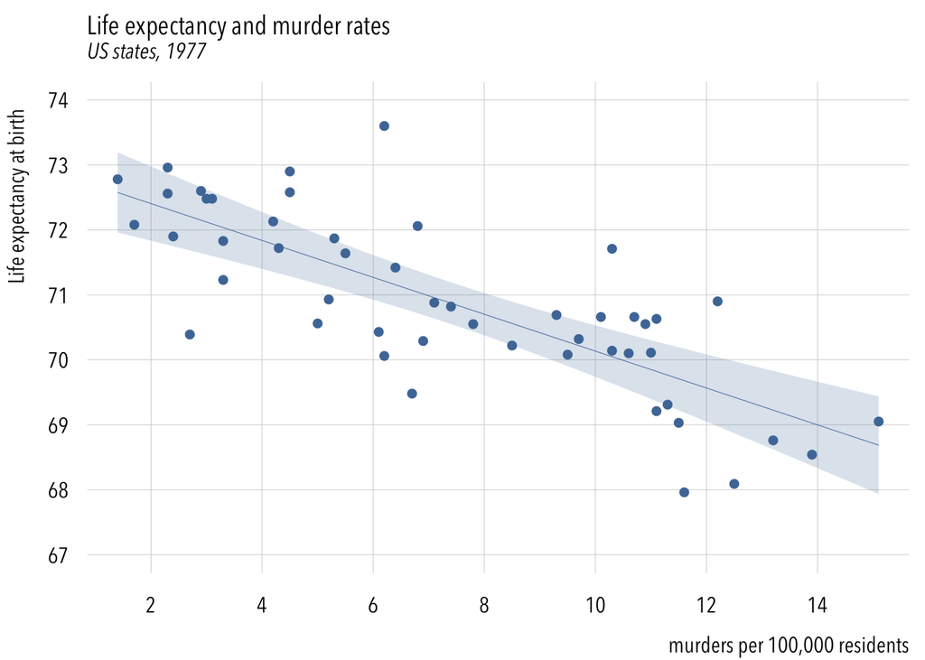

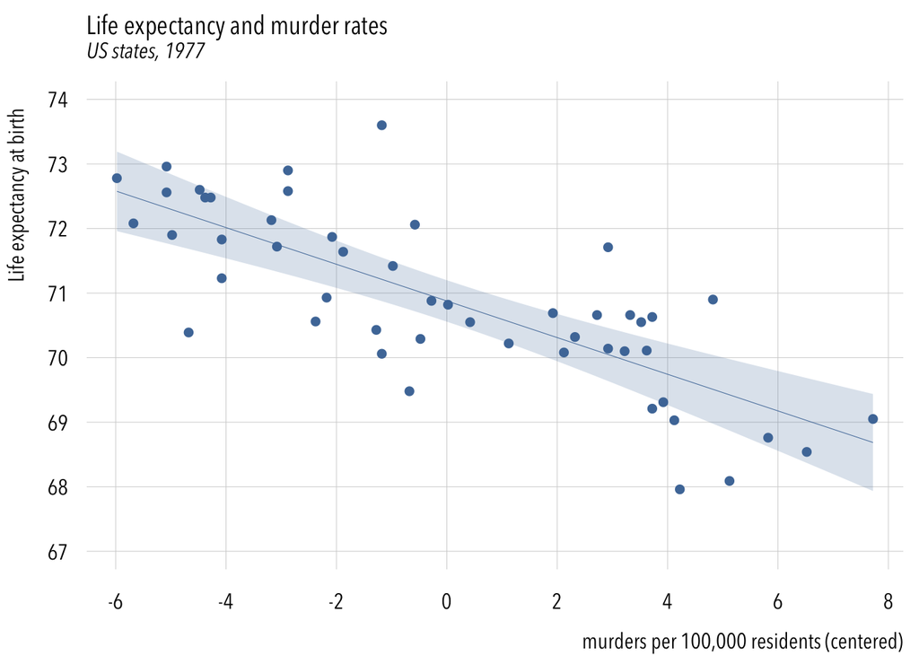

# Question 2c: Change the units of the predictor

Create a transformed predictor by standardizing `murder`.

## 2c(i). Create `murder_std` and refit the model

## 2c(ii). Report SSE(A), SSE(C), PRE, and F again

Compute SSE, PRE, and F again and compare them to 2a and 2b.

All values for SSE, PRE, and F are the same between the three models.

```
[1] 74.98865
```

```
Analysis of Variance Table

Model 1: life_exp ~ 1
Model 2: life_exp ~ 1 + murder_std
  Res.Df    RSS Df Sum of Sq      F   Pr(>F)
1     49 88.299
2     48 34.461  1    53.838 74.989 2.26e-11 ***
---
Signif. codes:  0 '***' 0.001 '**' 0.01 '*' 0.05 '.' 0.1 ' ' 1
```

```
[1] 2.26007e-11
```

|  | MC | MA |
| --- | --- | --- |
| (Intercept) | 70.879 | 70.879 |
|  | (0.190) | (0.120) |
| murder_std |  | -1.048 |
|  |  | (0.121) |
| Num.Obs. | 50 | 50 |
| R2 | 0.000 | 0.610 |
| F |  | 74.989 |
| p-value |  | 0.000 |

## 2c(iii). Interpret coefficients after rescaling

Write the prediction equation and interpret the slope carefully in the new units.

$$\widehat{\text{life_exp}} = 70.879 - 1.048 (\text{murder})$$

For every one standard deviation the murder rate is above the mean we expect life expectancy to decrease by 1.048 years.

# Question 3: Predicted values and what transformations do (and do not) change

You now have three versions of the same basic relationship:

1. using `murder`
2. using `murder_c`
3. using `murder_std`

## 3a. Predicted life expectancy at a specific murder rate

Using each of your three fitted Model A versions, compute the predicted life expectancy for a state with `murder` = 8.

Model A: 70.70198 years

Model A Centered: 70.70198 years

Model A Standardized: 70.70198 years

Show your work. (Be explicit about how you convert 8 into the appropriate value for `murder_c` and `murder_std`.)

```
       1
70.70198
```

```
       1
70.70198
```

```
       1
70.70198
```

## 3b. Summary paragraph

Write a brief summary explaining what you learned about transforming a predictor:

- How do these transformations affect the estimated intercept and slope?
  - They do change the intercept and slope. The original model and the centered model have the same slope, but different intercepts. The centered model and the standardized model have the same intercept and different slopes. The original and standardized model have different intercepts and slopes.
- Do they change predicted values (when transformed consistently)?
  - The predicted values did not change when transformed consistently.
- Do they change overall goodness of fit (SSE, PRE, $F$)?
  - Transforming a predictor has no impact on SSE, PRE, or F.

# Project application

Do the same thing with an outcome and predictor of your choice from your own dataset. Use three transformations:

Interpret the intercepts and slopes for each of the three models. Compare the fit statistics for each of the three models.

```
# A tibble: 47 × 3
   state                abortion_rate cpc_rate
   <chr>                        <dbl>    <dbl>
 1 Alabama                        6.6   0.0533
 2 Alaska                         8.5   0.0693
 3 Arizona                       10     0.0335
 4 Arkansas                       5.4   0.0686
 5 Colorado                       9.7   0.0425
 6 Connecticut                   14.8   0.0292
 7 Delaware                       9.8   0.0269
 8 District of Columbia          21.8   0.0113
 9 Florida                       20.3   0.0384
10 Georgia                       18.8   0.0396
# ℹ 37 more rows
```

```
# A tibble: 1 × 6
  mean_abor var_abor sd_abor mean_cpc  var_cpc sd_cpc
      <dbl>    <dbl>   <dbl>    <dbl>    <dbl>  <dbl>
1      9.60     24.8    4.98   0.0472 0.000419 0.0205
```

```
[1] 46
```

```
[1] 45
```

```
[1] 10.78038
```

```
Analysis of Variance Table

Model 1: abortion_rate ~ 1
Model 2: abortion_rate ~ 1 + cpc_rate
  Res.Df     RSS Df Sum of Sq     F   Pr(>F)
1     46 1141.68
2     45  921.03  1    220.65 10.78 0.001989 **
---
Signif. codes:  0 '***' 0.001 '**' 0.01 '*' 0.05 '.' 0.1 ' ' 1
```

```
[1] 0.001989359
```

|  | MC | MA |
| --- | --- | --- |
| (Intercept) | 9.604 | 14.654 |
|  | (0.727) | (1.673) |
| cpc_rate |  | -107.016 |
|  |  | (32.594) |
| Num.Obs. | 47 | 47 |
| R2 | 0.000 | 0.193 |
| F |  | 10.780 |
| p-value |  | 0.002 |

```
[1] 46
```

```
[1] 45
```

```
[1] 10.78038
```

```
Analysis of Variance Table

Model 1: abortion_rate ~ 1
Model 2: abortion_rate ~ 1 + cpc_n
  Res.Df     RSS Df Sum of Sq     F   Pr(>F)
1     46 1141.68
2     45  921.03  1    220.65 10.78 0.001989 **
---
Signif. codes:  0 '***' 0.001 '**' 0.01 '*' 0.05 '.' 0.1 ' ' 1
```

```
[1] 0.001989359
```

|  | MC | MA |
| --- | --- | --- |
| (Intercept) | 9.604 | 13.487 |
|  | (0.727) | (1.354) |
| cpc_n |  | -10.672 |
|  |  | (3.250) |
| Num.Obs. | 47 | 47 |
| R2 | 0.000 | 0.193 |
| F |  | 10.780 |
| p-value |  | 0.002 |

```
[1] 46
```

```
[1] 45
```

```
[1] 10.78038
```

```
Analysis of Variance Table

Model 1: abortion_std ~ 1
Model 2: abortion_std ~ 1 + cpc_std
  Res.Df   RSS Df Sum of Sq     F   Pr(>F)
1     46 46.00
2     45 37.11  1    8.8902 10.78 0.001989 **
---
Signif. codes:  0 '***' 0.001 '**' 0.01 '*' 0.05 '.' 0.1 ' ' 1
```

```
[1] 0.001989359
```

|  | MC | MA |
| --- | --- | --- |
| (Intercept) | -0.000 | -0.000 |
|  | (0.146) | (0.132) |
| cpc_std |  | -0.440 |
|  |  | (0.134) |
| Num.Obs. | 47 | 47 |
| R2 | 0.000 | 0.193 |
| F |  | 10.780 |
| p-value |  | 0.002 |